# Storm Analysis

Xiangzhu Long

## Synopsis

1.Observe the data and prepocess it to get the clean data;

2.Exlpore the impact of different estimators on the population health, find that **tornados**, are most harmful.

3.Exlpore the impact of different estimators on the economy , find that **floods** are most harmful.

## Analysis

### Loading and preprocessing the data

```r
# Load the data
data_raw <- read.csv("data/repdata-data-StormData.csv", stringsAsFactors = FALSE)

# Observe tha raw data
d <- dim(data_raw)
```

This data set contains 902297 observations and 37 features.

```r
head(data_raw, n = 2)
```

STATE__ BGN_DATE BGN_TIME TIME_ZONE COUNTY COUNTYNAME STATE 1 1 4/18/1950 0:00:00 0130 CST 97 MOBILE AL 2 1 4/18/1950 0:00:00 0145 CST 3 BALDWIN AL EVTYPE BGN_RANGE BGN_AZI BGN_LOCATI END_DATE END_TIME COUNTY_END 1 TORNADO 0 0 2 TORNADO 0 0 COUNTYENDN END_RANGE END_AZI END_LOCATI LENGTH WIDTH F MAG FATALITIES 1 NA 0 14 100 3 0 0 2 NA 0 2 150 2 0 0 INJURIES PROPDMG PROPDMGEXP CROPDMG CROPDMGEXP WFO STATEOFFIC ZONENAMES 1 15 25.0 K 0  
2 0 2.5 K 0  
LATITUDE LONGITUDE LATITUDE_E LONGITUDE_ REMARKS REFNUM 1 3040 8812 3051 8806 1 2 3042 8755 0 0 2

```r
# Process the data
data <- data_raw[,c('EVTYPE','FATALITIES','INJURIES', 'PROPDMG', 'PROPDMGEXP', 'CROPDMG', 'CROPDMGEXP')]

# Convert the damage degree to numeric value
data$PROPDMGNUM = 0
data[data$PROPDMGEXP == "H", ]$PROPDMGNUM = data[data$PROPDMGEXP == "H", ]$PROPDMG * 10^2
data[data$PROPDMGEXP == "K", ]$PROPDMGNUM = data[data$PROPDMGEXP == "K", ]$PROPDMG * 10^3
data[data$PROPDMGEXP == "M", ]$PROPDMGNUM = data[data$PROPDMGEXP == "M", ]$PROPDMG * 10^6
data[data$PROPDMGEXP == "B", ]$PROPDMGNUM = data[data$PROPDMGEXP == "B", ]$PROPDMG * 10^9

data$CROPDMGNUM = 0
data[data$CROPDMGEXP == "H", ]$CROPDMGNUM = data[data$CROPDMGEXP == "H", ]$CROPDMG * 10^2
data[data$CROPDMGEXP == "K", ]$CROPDMGNUM = data[data$CROPDMGEXP == "K", ]$CROPDMG * 10^3
data[data$CROPDMGEXP == "M", ]$CROPDMGNUM = data[data$CROPDMGEXP == "M", ]$CROPDMG * 10^6
data[data$CROPDMGEXP == "B", ]$CROPDMGNUM = data[data$CROPDMGEXP == "B", ]$CROPDMG * 10^9
```

### Results

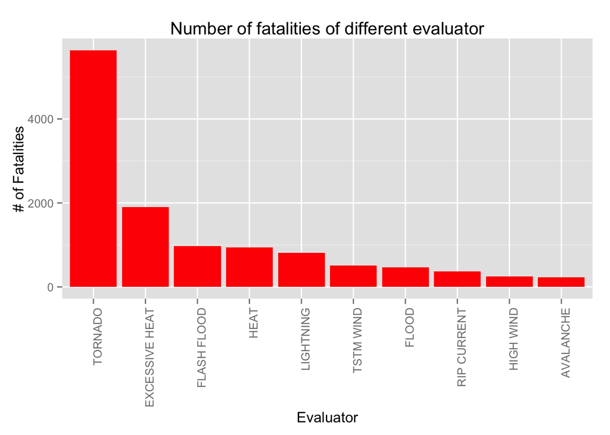

```r
library(ggplot2)
# Plot the number of fatalities of different evaluator.
evaluator <- aggregate(FATALITIES ~ EVTYPE, data = data, sum)
evaluator <- evaluator[order(-evaluator$FATALITIES), ][1:10, ]
evaluator$EVTYPE <- factor(evaluator$EVTYPE, levels = evaluator$EVTYPE)

ggplot(evaluator, aes(x = EVTYPE, y = FATALITIES)) +
  geom_bar(stat = "identity", fill = "red", las = 3) +
  theme(axis.text.x = element_text(angle = 90, hjust = 1)) +
  xlab("Evaluator") + ylab("# of Fatalities") +
  ggtitle("Number of fatalities of different evaluator")
```

The figure shows that **Tornado**, **Excessive heat** and **Flash flood** cause the most serious fatalities, while **Avalanche**, **High wind** and **Rip current* have the less impact.

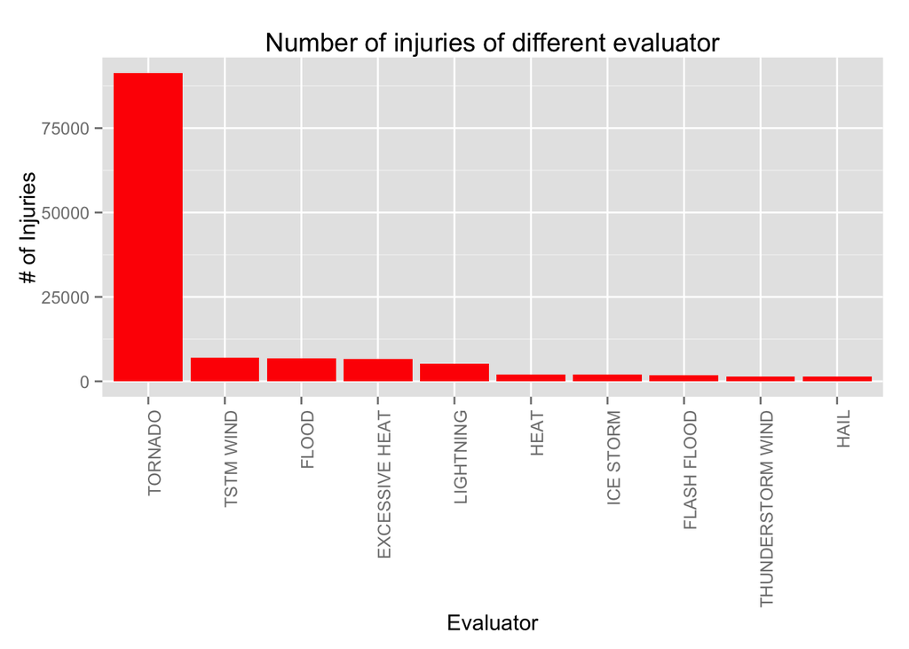

```r
# Plot the number of injuries of different evaluator.
injuries <- aggregate(INJURIES ~ EVTYPE, data = data, sum)
injuries <- injuries[order(-injuries$INJURIES), ][1:10, ]
injuries$EVTYPE <- factor(injuries$EVTYPE, levels = injuries$EVTYPE)

ggplot(injuries, aes(x = EVTYPE, y = INJURIES)) +
  geom_bar(stat = "identity", fill = "red", las = 3) +
  theme(axis.text.x = element_text(angle = 90, hjust = 1)) +
  xlab("Evaluator") + ylab("# of Injuries") +
  ggtitle("Number of injuries of different evaluator")
```

The figure shows that **Tornado*, **Tstm wind** and **Flood** have the most harmful influence on the population health, while **Hail**, **Thunderstorm wind** and **Flash flood** have the less impact.

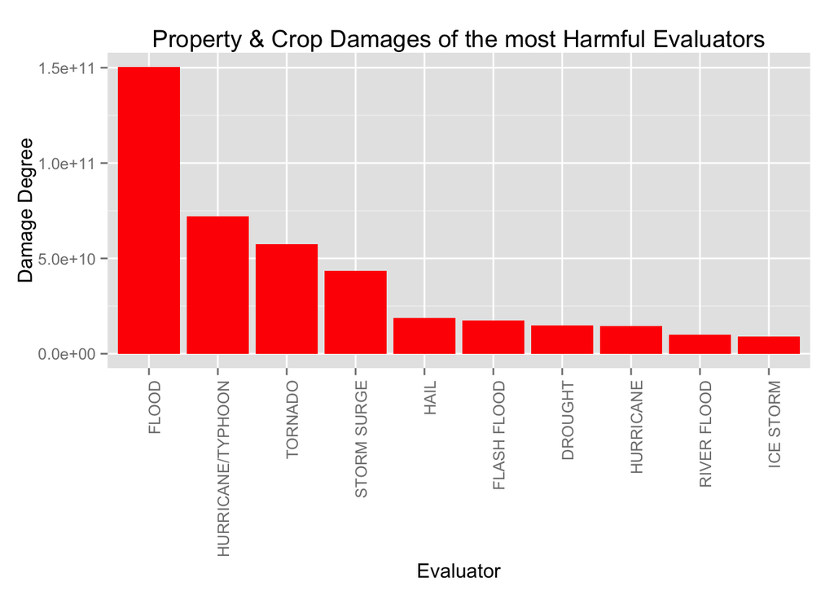

```r
# Plot the damage degree with the most harmful evaluators.
damages <- aggregate(PROPDMGNUM + CROPDMGNUM ~ EVTYPE,
                     data = data, sum)
names(damages) = c("EVTYPE", "DAMAGES")
damages <- damages[order(-damages$DAMAGES), ][1:10, ]
damages$EVTYPE <- factor(damages$EVTYPE, levels = damages$EVTYPE)

ggplot(damages, aes(x = EVTYPE, y = DAMAGES)) +
  geom_bar(stat = "identity", fill = "red", las = 3) +
  theme(axis.text.x = element_text(angle = 90, hjust = 1)) +
  xlab("Evaluator") + ylab("Damage Degree") +
  ggtitle("Property & Crop Damages of the most Harmful Evaluators")
```

The figure shows that **Fload**, **Hurricanetyphoon** and **Tornado** have the most harmful influence on the economics, while **Ice storml**, **River flood** and **Hurricane** have the less impact.